# Negative Control Experiment

Alyssa Frazee

August 13, 2014

We will need the GEUVADIS FPKM Ballgown object for this analysis. [Download here](http://files.figshare.com/1625419/fpkm.rda).

```r
library(ballgown)
load('fpkm.rda')
head(pData(fpkm))
```

```
##       dirname population IndividualID             SampleID UseThisDup RIN
## 20    HG00096        GBR      HG00096 HG00096.1.M_111124_6          1 8.4
## 211   HG00097        GBR      HG00097 HG00097.7.M_120219_2          1 9.2
## 408   HG00099        GBR      HG00099 HG00099.5.M_120131_3          1 9.3
## 526 HG00099_2        GBR      HG00099 HG00099.1.M_120209_6          0 9.3
## 186   HG00100        GBR      HG00100 HG00100.2.M_111215_8          1 9.5
## 287   HG00101        GBR      HG00101 HG00101.1.M_111124_4          1 9.3
```

For the negative control, we’ll compare two random groups of individuals from the same population.

```r
table(pData(fpkm)$population[pData(fpkm)$UseThisDup==1])
```

```
##
## CEU FIN GBR TSI YRI
##  92  95  95  93  89
```

The FIN and GBR populations have the most replicates, so let’s use FIN. (Note that we’re only considering reps marked by the original GEUVADIS researchers as “use this duplicate.”)

```r
control = subset(fpkm, 'population == "FIN" & UseThisDup == 1', genomesubset=FALSE)
set.seed(1247)
pData(control)$randgroup = sample(c(0,1), size=nrow(pData(control)), replace=TRUE)
table(pData(control)$randgroup)
```

```
##
##  0  1
## 48 47
```

So we will do a 48 vs. 47 comparison.

### Ballgown results

```r
system.time(negative_results_all <- stattest(control, feature='transcript', meas='FPKM', covariate='randgroup'))
```

```
##    user  system elapsed
##  16.731   1.558  18.363
```

We will only keep/analyze results from transcripts whose mean FPKM value across the FIN samples is greater than 0.01 (and re-adjust p-values accordingly):

```r
negative_results = negative_results_all[rowMeans(texpr(control)) >= 0.01,]
nrow(negative_results)
```

```
## [1] 85509
```

```r
negative_results$qval = p.adjust(negative_results$pval, 'fdr')
min(negative_results$qval, na.rm=TRUE)
```

```
## [1] 1
```

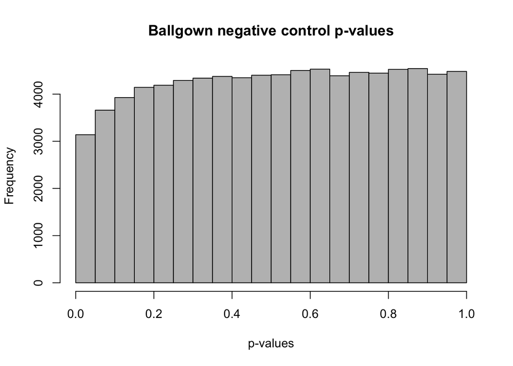

```r
hist(negative_results$pval, breaks=30, col='gray', xlab='p-values', main='Ballgown negative control p-values')
```

Ballgown’s minimum q-value from this experiment is approximately 1, and the p-value histogram is approximately uniformly distributed. These two properties are to be expected, since there was no signal. This provides evidence that a linear modeling framework for differential expression testing at the transcript level is not too liberal.

### exon-level analysis / comparison to EdgeR

For this analysis we will need the GEUVADIS “rcount” (per-exon read count) Ballgown object, [available here](http://files.figshare.com/1625424/rcount.rda).

```r
load('rcount.rda')
excontrol = subset(rcount, 'population == "FIN" & UseThisDup == 1', genomesubset=FALSE)
stopifnot(all(pData(excontrol)$dirname == pData(control)$dirname))
pData(excontrol)$randgroup = pData(control)$randgroup
exon_results_all = stattest(excontrol, feature='exon', meas='rcount', covariate='randgroup')
```

```r
exon_results = exon_results_all[rowSums(eexpr(excontrol)>1) > 20,] #at least 20 samples should have at least 3 reads in the exon
exon_results$qval = p.adjust(exon_results$pval, 'fdr')
min(exon_results$qval)
```

```
## [1] 1
```

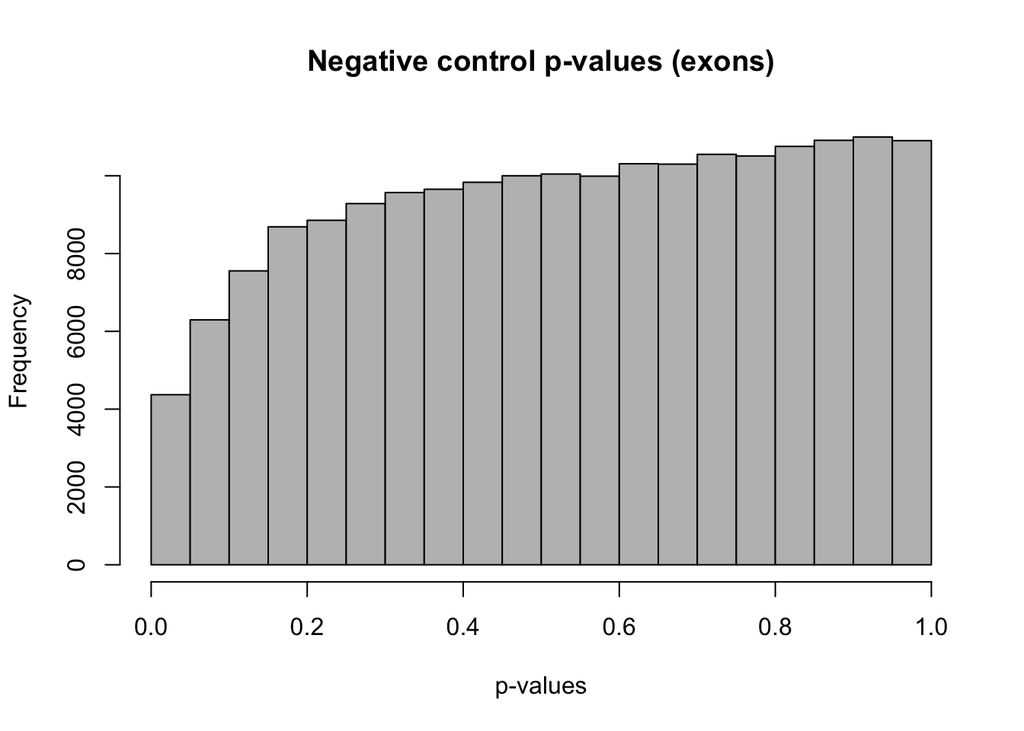

```r
hist(exon_results$pval, breaks=30, col='gray', xlab='p-values', main='Negative control p-values (exons)')
```

A similar analysis performed in EdgeR gives the following results:

```r
library(edgeR)
counts = eexpr(excontrol)
grp = as.factor(pData(excontrol)$randgroup)
d = DGEList(counts=counts, group=grp)
d = calcNormFactors(d)
cps = cpm(d)
d = d[rowSums(cps>=1)>20,] #filter: at least 20 samples should have at least 1cpm
nrow(d) #number of exons left
```

```
## [1] 72599
```

```r
mm = model.matrix(~grp)
d = estimateGLMCommonDisp(d, mm)
d = estimateGLMTrendedDisp(d, mm)
d = estimateGLMTagwiseDisp(d, mm)
fit = glmFit(d, mm)
lrt = glmLRT(fit, coef=2) #interesting coefficient is group, not intercept
res = topTags(lrt, nrow(d)) #get all results
min(res$table$FDR)
```

```
## [1] 0.003385
```

```r
sum(res$table$FDR < 0.05)
```

```
## [1] 2
```

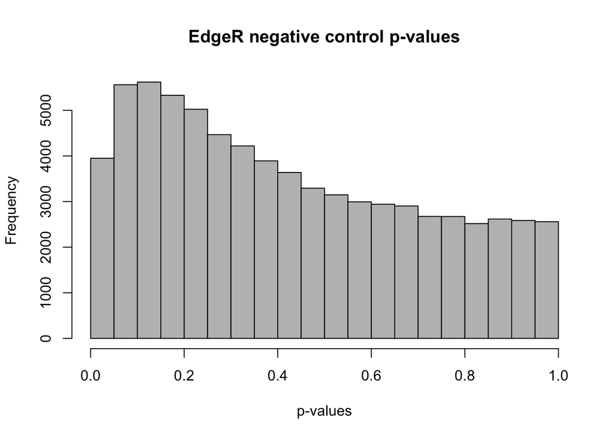

```r
hist(res$table$PValue, breaks=30, col='gray', xlab='p-values', main='EdgeR negative control p-values')
```

### comparison to Cuffdiff

We ran Cuffdiff 2.2.1 on this same 48 vs. 47 comparison (see `cuffdiff.sh`). This code creates the isoform-level p-value histogram:

```r
cuff = read.table('cuffdiff/isoform_exp.diff', header=TRUE, sep='\t')
table(cuff$status)
```

```
##
## HIDATA NOTEST     OK
##   1261 308006  24907
```

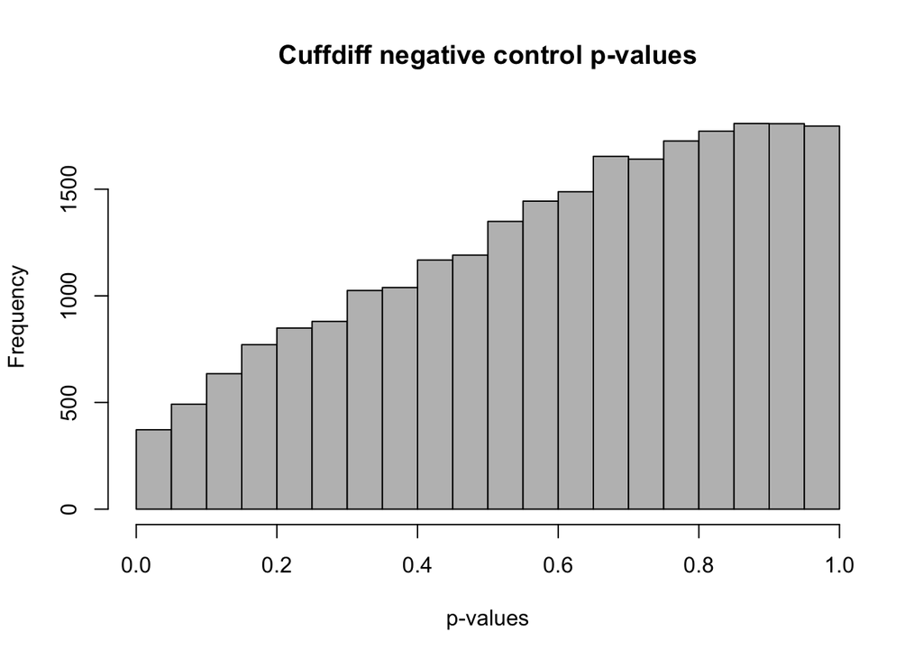

```r
hist(cuff$p_value[cuff$status=="OK"], xlab='p-values', main='Cuffdiff negative control p-values', breaks=30, col='gray')
```

This p-value histogram is not uniformly distributed, which means significance estimates and multiple testing correction are likely still problematic, even with the newest version of Cuffdiff as of August 2014. Additionally, this 4-core Cuffdiff job took 69 hours and 147G of memory. This could be sped up a bit with the new Cuffquant workflow, though our simulation timing results suggest that Tablemaker is slightly faster than Cuffquant, and that the Cuffdiff portion of the Cuffquant/Cuffdiff workflow is orders of magnitude slower than Ballgown’s default statistical methods (or other DE methods like EdgeR or limma). For comparison, Ballgown’s statistical models took about 18 seconds on this dataset.